# practical_workshop_in_deep_learning_assignment1

```python
from google.colab import drive
drive.flush_and_unmount()
drive.mount('/content/drive')
```

```
Drive not mounted, so nothing to flush and unmount.
```

```python
!cp -r /content/drive/MyDrive/humpback-whale-identification /content/humpback
```

```python
!pip install -q kaggle
from google.colab import files
files.upload()
!mkdir -p ~/.kaggle
!cp kaggle.json ~/.kaggle/
!chmod 600 ~/.kaggle/kaggle.json
!kaggle competitions download -c 'humpback-whale-identification'
!unzip -q humpback-whale-identification.zip -d /content/humpback
```

```python
import os

# 1. Clean up any previous failed attempts
!rm -rf /content/humpback

# 2. Create the destination directory
!mkdir -p /content/humpback

# 3. Copy the ZIP file from Drive to Colab VM (Fast)
# Change 'humpback-whale-identification.zip' to your actual zip filename if different
!cp "/content/drive/MyDrive/humpback-whale-identification.zip" /content/humpback_data.zip

# 4. Unzip directly into the target folder (Fast)
!unzip -q /content/humpback_data.zip -d /content/humpback

# 5. Clean up the zip file to save space
!rm /content/humpback_data.zip

print("Data successfully unzipped to /content/humpback")
print(f"Files in folder: {len(os.listdir('/content/humpback'))}")
```

[output not shown]

```python
# imports
import matplotlib.pyplot as plt
import numpy as np
from PIL import Image
import os
import random
import pandas as pd
import seaborn as sns
from collections import defaultdict
import torch
import torch.nn as nn
import torch.optim as optim
from torch.utils.data import Dataset, DataLoader, Subset
from sklearn.model_selection import StratifiedKFold
import torch.nn.functional as F
from torchvision import models, transforms
from sklearn.preprocessing import LabelEncoder
from sklearn.ensemble import RandomForestClassifier
from sklearn.model_selection import cross_val_score
from sklearn.decomposition import PCA
from tqdm import tqdm
from torch.utils.data import DataLoader

# constants
TRAIN_DIR = "/content/humpback/train"
CSV_PATH = "/content/humpback/train.csv"
NUM_CLASSES_TO_USE = 15
BATCH_SIZE = 32
NUM_EPOCHS = 20
K_FOLDS = 5
```

```python
# handling the data
full_df = pd.read_csv(CSV_PATH)
top_classes = full_df['Id'].value_counts().index[1:NUM_CLASSES_TO_USE+1]
df = full_df[full_df['Id'].isin(top_classes)].reset_index(drop=True)

# Extract one category for question 2e
chosen_id = "w_23a388d"
df_chosen = df[df["Id"] == chosen_id]
df_other = df[df["Id"] != chosen_id].copy()

# Map class IDs to numerical labels
class_to_idx = {cls_name: i for i, cls_name in enumerate(top_classes)}
df_other = df_other.copy()
df_other['label_idx'] = df_other['Id'].map(class_to_idx)
df['label_idx'] = df['Id'].map(class_to_idx)

# Custom Dataset Class
class WhaleDataset(Dataset):
    def __init__(self, dataframe, root_dir, transform=None):
        self.df = dataframe.copy()
        self.root_dir = root_dir
        self.transform = transform


    def __len__(self):
        return len(self.df)

    def __getitem__(self, idx):
        row = self.df.iloc[idx]
        img_name = row['Image']
        label = row['label_idx']
        img_path = os.path.join(self.root_dir, img_name)

        image = Image.open(img_path).convert('RGB')
        if self.transform:
            image = self.transform(image)

        return image, label
```

# Part 1

**1a**

```
Total number of training images: 25361
Total unique whale classes (IDs): 5005

Most common whale: new_whale with 9664 images
Least common whale: w_6cb0480 with 1 images
```

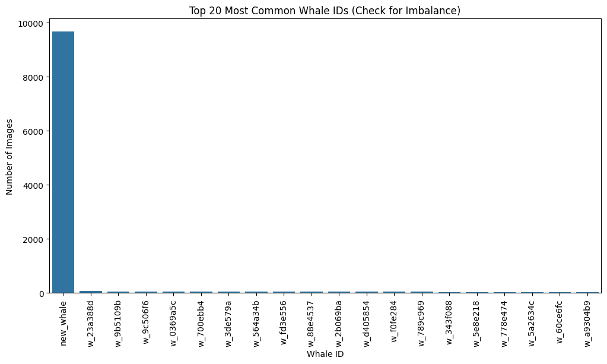

```
Sample of image sizes (Width, Height): [(1050, 700), (758, 325), (1050, 497), (1050, 525), (1050, 525)]
```

```python
# Basic Data Stats
print(f"Total number of training images: {len(full_df)}")
print(f"Total unique whale classes (IDs): {full_df['Id'].nunique()}")

# Check for Class Imbalance
class_counts = full_df['Id'].value_counts()
print(f"\nMost common whale: {class_counts.index[0]} with {class_counts.iloc[0]} images")
print(f"Least common whale: {class_counts.index[-1]} with {class_counts.iloc[-1]} images")

# Visualize the Distribution (Top 20 classes)
plt.figure(figsize=(12, 6))
sns.barplot(x=class_counts[:20].index, y=class_counts[:20].values)
plt.xticks(rotation=90)
plt.title("Top 20 Most Common Whale IDs (Check for Imbalance)")
plt.xlabel("Whale ID")
plt.ylabel("Number of Images")
plt.show()

# Check Image Dimensions (Preprocessing needs)
# We check the shape of the first 100 images to see if they vary
shapes = []
for img_name in full_df['Image'].iloc[:100]:
    img_path = os.path.join(TRAIN_DIR, img_name)
    with Image.open(img_path) as img:
        shapes.append(img.size) # (width, height)

print(f"\nSample of image sizes (Width, Height): {shapes[:5]}")
```

**1b.** Each sample contains an image and a label. The images have different sizes so we should resize them to be in the same size. The images were taken from different angles and in different lighting so we can augment the data, the model should work well on the augmented data.

**1c.** As we can see above, the dataset is extremely imbalanced, as there's almost 10000 whales as "new whale" which means they are unidentified, while specific whales have only a couple of images because of that we will use the 15 classes with the most samples excluding new whale.

```
Preparing Data Subset...
Total number of training images: 714
Total unique whale classes (IDs): 14

Most common whale: w_9b5109b with 65 images
Least common whale: w_343f088 with 40 images
```

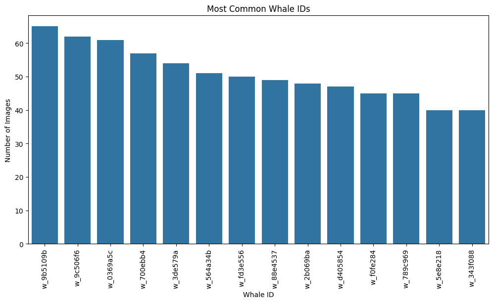

```
Sample of image sizes (Width, Height): [(1050, 700), (1050, 601), (1050, 700), (1050, 600), (1050, 600)]
```

```python
# Basic Data Stats
print(f"Total number of training images: {len(df_other)}")
print(f"Total unique whale classes (IDs): {df_other['Id'].nunique()}")

# Check for Class Imbalance
class_counts = df_other['Id'].value_counts()
print(f"\nMost common whale: {class_counts.index[0]} with {class_counts.iloc[0]} images")
print(f"Least common whale: {class_counts.index[-1]} with {class_counts.iloc[-1]} images")

# Visualize the Distribution
plt.figure(figsize=(12, 6))
sns.barplot(x=class_counts.index, y=class_counts.values)
plt.xticks(rotation=90)
plt.title("Most Common Whale IDs")
plt.xlabel("Whale ID")
plt.ylabel("Number of Images")
plt.show()

# Check Image Dimensions (Preprocessing needs)
# We check the shape of the first 100 images to see if they vary
shapes = []
for img_name in df_other['Image'].iloc[:100]:
    img_path = os.path.join(TRAIN_DIR, img_name)
    with Image.open(img_path) as img:
        shapes.append(img.size) # (width, height)

print(f"\nSample of image sizes (Width, Height): {shapes[:5]}")
```

**1d** In the Kaggle leaderboard there are contestants that have achieved a score of about 97% accuracy they used transfer learning with the senet154 model and they did 4 fold cross validation.

**1e**

[output not shown]

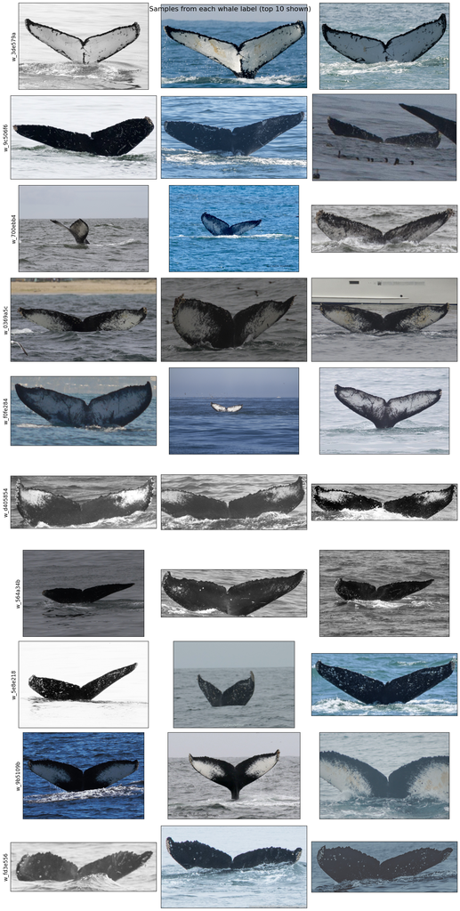

```python
NUM_SAMPLES_PER_CLASS = 3

# Group images by label
label_to_images = defaultdict(list)
for idx, row in df_other.iterrows():
    label_to_images[row['Id']].append(row['Image'])

# Pick a few labels to visualize (if too many)
selected_labels = list(label_to_images.keys())[:10]  # adjust 10 to more/fewer

plt.figure(figsize=(15, len(selected_labels) * 3))

for i, label in enumerate(selected_labels):
    images = label_to_images[label][:NUM_SAMPLES_PER_CLASS]  # pick a few
    for j, img_name in enumerate(images):
        img_path = os.path.join(TRAIN_DIR, img_name)
        img = Image.open(img_path).convert("RGB")

        ax = plt.subplot(len(selected_labels), NUM_SAMPLES_PER_CLASS, i*NUM_SAMPLES_PER_CLASS + j + 1)
        plt.imshow(img)
        if j == 0:
            ax.set_ylabel(label, fontsize=12)
        plt.xticks([])
        plt.yticks([])

plt.suptitle("Samples from each whale label (top 10 shown)", fontsize=16)
plt.tight_layout()
plt.show()
```

# Part 2

```
Training on subset: 714 images, 15 classes.
Using device: cuda

--- FOLD 1/5 ---
Epoch [1/20] Loss: 12.9816 | Val Acc: 18.18%
Epoch [2/20] Loss: 3.0025 | Val Acc: 27.97%
Epoch [3/20] Loss: 2.1118 | Val Acc: 27.97%
Epoch [4/20] Loss: 1.8405 | Val Acc: 36.36%
Epoch [5/20] Loss: 1.5851 | Val Acc: 37.76%
Epoch [6/20] Loss: 1.4713 | Val Acc: 39.86%
Epoch [7/20] Loss: 1.2767 | Val Acc: 41.96%
Epoch [8/20] Loss: 1.1224 | Val Acc: 41.96%
Epoch [9/20] Loss: 1.0810 | Val Acc: 44.06%
Epoch [10/20] Loss: 0.8779 | Val Acc: 42.66%
Epoch [11/20] Loss: 0.7964 | Val Acc: 49.65%
Epoch [12/20] Loss: 0.6743 | Val Acc: 51.75%
Epoch [13/20] Loss: 0.5307 | Val Acc: 52.45%
Epoch [14/20] Loss: 0.4329 | Val Acc: 51.05%
Epoch [15/20] Loss: 0.3463 | Val Acc: 51.75%
Epoch [16/20] Loss: 0.2241 | Val Acc: 51.75%
Epoch [17/20] Loss: 0.1931 | Val Acc: 55.94%
Epoch [18/20] Loss: 0.1273 | Val Acc: 55.24%
Epoch [19/20] Loss: 0.0896 | Val Acc: 55.94%
Epoch [20/20] Loss: 0.0631 | Val Acc: 59.44%

--- FOLD 2/5 ---
Epoch [1/20] Loss: 14.9497 | Val Acc: 16.78%
Epoch [2/20] Loss: 2.7810 | Val Acc: 20.98%
Epoch [3/20] Loss: 1.9787 | Val Acc: 31.47%
Epoch [4/20] Loss: 1.6971 | Val Acc: 36.36%
Epoch [5/20] Loss: 1.4947 | Val Acc: 34.27%
Epoch [6/20] Loss: 1.3486 | Val Acc: 41.26%
Epoch [7/20] Loss: 1.2683 | Val Acc: 45.45%
Epoch [8/20] Loss: 1.0024 | Val Acc: 41.26%
Epoch [9/20] Loss: 0.8566 | Val Acc: 46.15%
Epoch [10/20] Loss: 0.7951 | Val Acc: 41.96%
Epoch [11/20] Loss: 0.6924 | Val Acc: 44.06%
Epoch [12/20] Loss: 0.5652 | Val Acc: 46.85%
Epoch [13/20] Loss: 0.4869 | Val Acc: 46.15%
Epoch [14/20] Loss: 0.3850 | Val Acc: 50.35%
```

[output cut: 67 more lines]

```
Epoch [16/20] Loss: 0.0163 | Val Acc: 69.01%
Epoch [17/20] Loss: 0.0139 | Val Acc: 69.01%
Epoch [18/20] Loss: 0.0123 | Val Acc: 67.61%
Epoch [19/20] Loss: 0.0106 | Val Acc: 68.31%
Epoch [20/20] Loss: 0.0095 | Val Acc: 69.01%
FINAL CROSS-VALIDATION RESULTS
Fold 1: Accuracy = 59.44%, Loss = 0.0631
Fold 2: Accuracy = 55.24%, Loss = 0.1053
Fold 3: Accuracy = 60.14%, Loss = 0.0764
Fold 4: Accuracy = 53.15%, Loss = 0.0436
Fold 5: Accuracy = 69.01%, Loss = 0.0095
Mean Cross-Validation Accuracy: 59.3972%
Mean Cross-Validation Loss: 0.0596

Plotting Results...
```

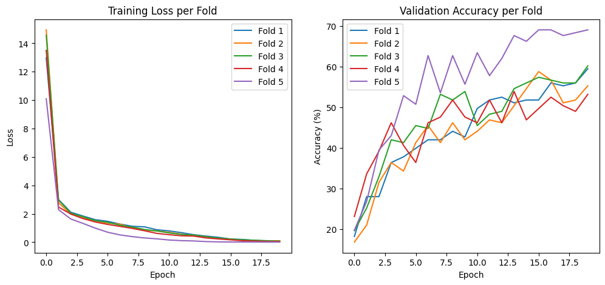

```python
print(f"Training on subset: {len(df_other)} images, {len(top_classes)} classes.")

# resizing the images
transform = transforms.Compose([
    transforms.Resize((128, 128)), # Smaller size for speed
    transforms.ToTensor(),
    transforms.Normalize(mean=[0.5, 0.5, 0.5], std=[0.5, 0.5, 0.5])
])

dataset = WhaleDataset(df_other, TRAIN_DIR, transform=transform)

# define custom model
class SimpleCNN(nn.Module):
    def __init__(self, num_classes):
        super(SimpleCNN, self).__init__()
        # Conv Block 1
        self.conv1 = nn.Conv2d(3, 32, kernel_size=3, padding=1)
        self.bn1 = nn.BatchNorm2d(32)
        self.relu = nn.ReLU()
        self.pool = nn.MaxPool2d(2, 2)

        # Conv Block 2
        self.conv2 = nn.Conv2d(32, 64, kernel_size=3, padding=1)
        self.bn2 = nn.BatchNorm2d(64)

        # Conv Block 3
        self.conv3 = nn.Conv2d(64, 128, kernel_size=3, padding=1)
        self.bn3 = nn.BatchNorm2d(128)

        # Fully Connected Layers
        self.flatten = nn.Flatten()
        # 128 channels * 16 * 16 (image size after 3 pools of 128x128)
        self.fc1 = nn.Linear(128 * 16 * 16, 512)
        self.fc2 = nn.Linear(512, num_classes)

    def forward(self, x):
        x = self.pool(self.relu(self.bn1(self.conv1(x))))
        x = self.pool(self.relu(self.bn2(self.conv2(x))))
        x = self.pool(self.relu(self.bn3(self.conv3(x))))
        x = self.flatten(x)
        x = self.relu(self.fc1(x))
        x = self.fc2(x)
        return x

#  K-fold cross validation loop
kfold = StratifiedKFold(n_splits=K_FOLDS, shuffle=True, random_state=42)
device = torch.device("cuda" if torch.cuda.is_available() else "cpu")
print(f"Using device: {device}")

# Store results for final report
fold_results = {}

labels = df_other['label_idx'].tolist()

for fold, (train_ids, val_ids) in enumerate(kfold.split(df_other, labels)):
    print(f"\n--- FOLD {fold+1}/{K_FOLDS} ---")

    # Init DataLoaders for this fold
    train_sub = Subset(dataset, train_ids)
    val_sub = Subset(dataset, val_ids)

    train_loader = DataLoader(train_sub, batch_size=BATCH_SIZE, shuffle=True)
    val_loader = DataLoader(val_sub, batch_size=BATCH_SIZE, shuffle=False)

    # Initial Model
    model = SimpleCNN(num_classes=len(top_classes)).to(device)
    criterion = nn.CrossEntropyLoss()
    optimizer = optim.Adam(model.parameters(), lr=0.001)

    history = {'train_loss': [], 'val_acc': []}

    # Training Loop
    for epoch in range(NUM_EPOCHS):
        model.train()
        running_loss = 0.0
        for images, labels in train_loader:
            images, labels = images.to(device), labels.to(device)

            optimizer.zero_grad()
            outputs = model(images)
            loss = criterion(outputs, labels)
            loss.backward()
            optimizer.step()
            running_loss += loss.item()

        avg_train_loss = running_loss / len(train_loader)
        history['train_loss'].append(avg_train_loss)

        # Validation Loop
        model.eval()
        correct = 0
        total = 0
        with torch.no_grad():
            for images, labels in val_loader:
                images, labels = images.to(device), labels.to(device)
                outputs = model(images)
                _, predicted = torch.max(outputs.data, 1)
                total += labels.size(0)
                correct += (predicted == labels).sum().item()

        val_acc = 100 * correct / total
        history['val_acc'].append(val_acc)

        print(f"Epoch [{epoch+1}/{NUM_EPOCHS}] Loss: {avg_train_loss:.4f} | Val Acc: {val_acc:.2f}%")

    fold_results[fold] = history

print("FINAL CROSS-VALIDATION RESULTS")


final_fold_acc = []
final_fold_loss = []

for fold in fold_results:
    fold_acc = fold_results[fold]['val_acc'][-1]       # last epoch accuracy
    fold_loss = fold_results[fold]['train_loss'][-1]   # last epoch loss
    final_fold_acc.append(fold_acc)
    final_fold_loss.append(fold_loss)
    print(f"Fold {fold+1}: Accuracy = {fold_acc:.2f}%, Loss = {fold_loss:.4f}")

# Averages
mean_acc = np.mean(final_fold_acc)
mean_loss = np.mean(final_fold_loss)

print(f"Mean Cross-Validation Accuracy: {mean_acc:.4f}%")
print(f"Mean Cross-Validation Loss: {mean_loss:.4f}")

# --- 4. VISUALIZATION  ---
print("\nPlotting Results...")
plt.figure(figsize=(12, 5))

# Plot Loss
plt.subplot(1, 2, 1)
for fold in fold_results:
    plt.plot(fold_results[fold]['train_loss'], label=f'Fold {fold+1}')
plt.title("Training Loss per Fold")
plt.xlabel("Epoch")
plt.ylabel("Loss")
plt.legend()

# Plot Accuracy
plt.subplot(1, 2, 2)
for fold in fold_results:
    plt.plot(fold_results[fold]['val_acc'], label=f'Fold {fold+1}')
plt.title("Validation Accuracy per Fold")
plt.xlabel("Epoch")
plt.ylabel("Accuracy (%)")
plt.legend()

plt.show()
```

### 2b

```python
# Make a list of filenames for validation set
val_filenames = [df_other.iloc[i]['Image'] for i in val_ids]

misclassified = []
predictions = []

pointer = 0  # to track position in val_filenames

with torch.no_grad():
    for images, labels in val_loader:
        images, labels = images.to(device), labels.to(device)
        outputs = model(images)
        _, predicted = torch.max(outputs, 1)

        predictions.extend(predicted.cpu().numpy())

        batch_size = labels.size(0)
        for i in range(batch_size):
            true_label = labels[i].item()
            pred_label = predicted[i].item()
            img_name = val_filenames[pointer + i]

            if pred_label != true_label:
                img_path = os.path.join(TRAIN_DIR, img_name)
                raw_img = Image.open(img_path).convert("RGB")
                misclassified.append((raw_img, true_label, pred_label, img_name))

        pointer += batch_size

print(f"Total misclassified: {len(misclassified)}")
```

```
Total misclassified: 44
```

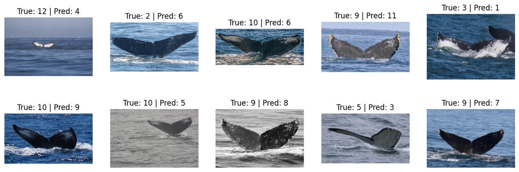

```python
#Displaying some misclassified images
import matplotlib.pyplot as plt

num_show = min(10, len(misclassified))  # show up to 10

plt.figure(figsize=(15, 5))
for i in range(num_show):
    img, true_label, pred_label, filename = misclassified[i]
    plt.subplot(2, 5, i+1)
    plt.imshow(img)
    plt.title(f"True: {true_label} | Pred: {pred_label}")
    plt.axis("off")
plt.show()
```

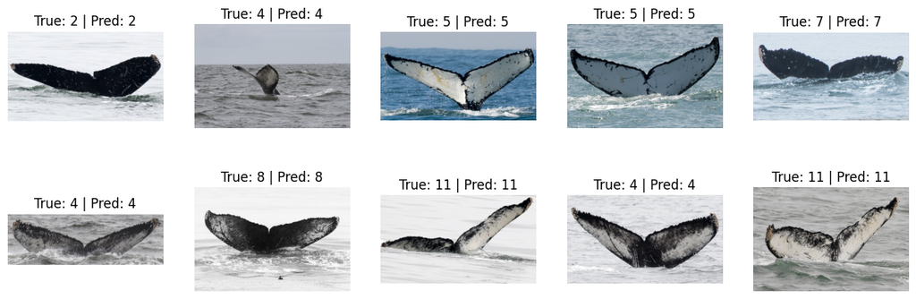

```python
#Displaying some of the correct images
# Make a list of filenames for validation set
val_filenames = [df_other.iloc[i]['Image'] for i in val_ids]

correct = []
predictions = []

pointer = 0  # to track position in val_filenames

with torch.no_grad():
    for images, labels in val_loader:
        images, labels = images.to(device), labels.to(device)
        outputs = model(images)
        _, predicted = torch.max(outputs, 1)

        predictions.extend(predicted.cpu().numpy())

        batch_size = labels.size(0)
        for i in range(batch_size):
            true_label = labels[i].item()
            pred_label = predicted[i].item()
            img_name = val_filenames[pointer + i]

            if pred_label == true_label:
                img_path = os.path.join(TRAIN_DIR, img_name)
                raw_img = Image.open(img_path).convert("RGB")
                correct.append((raw_img, true_label, pred_label, img_name))

        pointer += batch_size

num_show = min(10, len(correct))  # show up to 10

plt.figure(figsize=(15, 5))
for i in range(num_show):
    img, true_label, pred_label, filename = correct[i]
    plt.subplot(2, 5, i+1)
    plt.imshow(img)
    plt.title(f"True: {true_label} | Pred: {pred_label}")
    plt.axis("off")
plt.show()
```

There are several reasons why the model misclassifies images

1. In some images the lighting is less good
2. In some images the tail is very small compared to the ocean
3. Some of the different tail types are very similair
4. The tails of the whale are sometime showen from different angles

**2c**

3 ways to improve our model (Prioritized)

1. We can add RandomRotation library to help with tilted tails
2. We can use ColorJitter library to help with the different lighting of the images
3. We can crop the images if the tail is only in a small part of the image

```
Starting training on device: cuda

--- AUGMENTED RUN | FOLD 1/5 ---

--- AUGMENTED RUN | FOLD 2/5 ---

--- AUGMENTED RUN | FOLD 3/5 ---

--- AUGMENTED RUN | FOLD 4/5 ---

--- AUGMENTED RUN | FOLD 5/5 ---
FINAL CROSS-VALIDATION RESULTS
Mean Cross-Validation Accuracy: 53.2247%
Mean Cross-Validation Loss: 0.4674
```

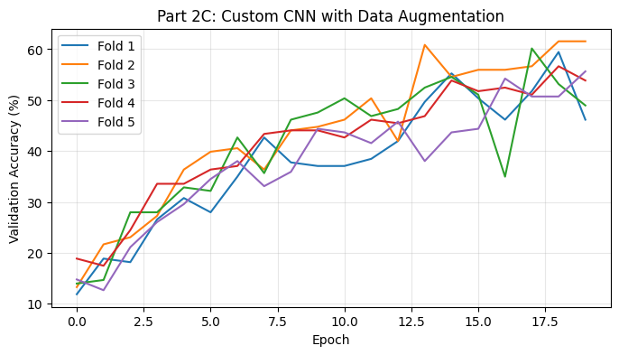

```python
# Data augmentation
transform = transforms.Compose([
    transforms.RandomRotation(degrees=10),
    transforms.ColorJitter(brightness=0.1, contrast=0.1),
    transforms.Resize((128, 128)),
    transforms.ToTensor(),
    transforms.Normalize(mean=[0.5,0.5,0.5], std=[0.5,0.5,0.5])
])

dataset = WhaleDataset(df_other, TRAIN_DIR, transform=transform)

# CUSTOM CNN
class SimpleCNN(nn.Module):
    def __init__(self, num_classes):
        super(SimpleCNN, self).__init__()
        self.conv1 = nn.Conv2d(3, 32, 3, padding=1)
        self.bn1 = nn.BatchNorm2d(32)
        self.conv2 = nn.Conv2d(32, 64, 3, padding=1)
        self.bn2 = nn.BatchNorm2d(64)
        self.conv3 = nn.Conv2d(64, 128, 3, padding=1)
        self.bn3 = nn.BatchNorm2d(128)
        self.relu = nn.ReLU()
        self.pool = nn.MaxPool2d(2,2)
        self.flatten = nn.Flatten()
        self.fc1 = nn.Linear(128*16*16, 512)
        self.fc2 = nn.Linear(512, num_classes)

    def forward(self, x):
        x = self.pool(self.relu(self.bn1(self.conv1(x))))
        x = self.pool(self.relu(self.bn2(self.conv2(x))))
        x = self.pool(self.relu(self.bn3(self.conv3(x))))
        x = self.flatten(x)
        x = self.relu(self.fc1(x))
        x = self.fc2(x)
        return x

# training loop
kfold = StratifiedKFold(n_splits=K_FOLDS, shuffle=True, random_state=42)
device = torch.device("cuda" if torch.cuda.is_available() else "cpu")
fold_results = {}
labels_list = df_other['label_idx'].tolist()

print(f"Starting training on device: {device}")

for fold, (train_ids, val_ids) in enumerate(kfold.split(df_other, labels_list)):
    print(f"\n--- AUGMENTED RUN | FOLD {fold+1}/{K_FOLDS} ---")

    train_sub = Subset(dataset, train_ids)
    val_sub = Subset(dataset, val_ids)
    train_loader = DataLoader(train_sub, batch_size=BATCH_SIZE, shuffle=True)
    val_loader = DataLoader(val_sub, batch_size=BATCH_SIZE, shuffle=False)

    num_classes = df_other['label_idx'].max() + 1  # FIX: ensure output layer matches labels
    model = SimpleCNN(num_classes=num_classes).to(device)

    criterion = nn.CrossEntropyLoss()
    optimizer = optim.Adam(model.parameters(), lr=0.001)

    history = {'train_loss': [], 'val_acc': []}

    for epoch in range(NUM_EPOCHS):
        model.train()
        running_loss = 0.0
        for images, labels in train_loader:
            images, labels = images.to(device), labels.to(device)

            optimizer.zero_grad()
            outputs = model(images)
            loss = criterion(outputs, labels)
            loss.backward()
            optimizer.step()
            running_loss += loss.item()

        avg_train_loss = running_loss / len(train_loader)
        history['train_loss'].append(avg_train_loss)
        # Validation
        model.eval()
        correct = 0
        total = 0
        with torch.no_grad():
            for images, labels in val_loader:
                images, labels = images.to(device), labels.to(device)
                outputs = model(images)
                _, predicted = torch.max(outputs.data,1)
                total += labels.size(0)
                correct += (predicted == labels).sum().item()

        val_acc = 100 * correct / total
        history['val_acc'].append(val_acc)
        print(f"Epoch {epoch+1}/{NUM_EPOCHS}: Val Acc {val_acc:.2f}%")

    fold_results[fold] = history

final_fold_acc = []
final_fold_loss = []

for fold in fold_results:
    fold_acc = fold_results[fold]['val_acc'][-1]       # last epoch accuracy
    fold_loss = fold_results[fold]['train_loss'][-1]   # last epoch loss
    final_fold_acc.append(fold_acc)
    final_fold_loss.append(fold_loss)

# Averages
mean_acc = np.mean(final_fold_acc)
mean_loss = np.mean(final_fold_loss)
print("FINAL CROSS-VALIDATION RESULTS")
print(f"Mean Cross-Validation Accuracy: {mean_acc:.4f}%")
print(f"Mean Cross-Validation Loss: {mean_loss:.4f}")

# Plot results
plt.figure(figsize=(8,4))
for fold in fold_results:
    plt.plot(fold_results[fold]['val_acc'], label=f'Fold {fold+1}')
plt.title("Part 2C: Custom CNN with Data Augmentation")
plt.xlabel("Epoch")
plt.ylabel("Validation Accuracy (%)")
plt.legend()
plt.grid(True, alpha=0.3)
plt.show()
```

Implementing data augmentation decreased validation accuracy after 20 epochs. This suggests that the augmentation acted as a strong regularizer, making the training task more difficult. Since the task is harder, it takes the model slower to train. However, it is possible that by running more epochs we would achieve better results.

**2d**

```python
N_TTA_AUGMENTATIONS = 5
model.eval()
criterion = nn.CrossEntropyLoss()

print(f"--- PART 2d: INFERENCE TIME AUGMENTATION (TTA) ---")
print(f"Aggregating {N_TTA_AUGMENTATIONS} predictions per image...")

correct_standard = 0
correct_tta = 0
total = 0

loss_standard_total = 0.0
loss_tta_total = 0.0

print(f"Processing {len(val_ids)} validation images...")

with torch.no_grad():
    for idx in val_ids:

        # Standart prediction
        img, label = dataset[idx]
        img_batch = img.unsqueeze(0).to(device)
        label_tensor = torch.tensor([label]).to(device)

        output = model(img_batch)

        # Standard loss
        loss_standard = criterion(output, label_tensor)
        loss_standard_total += loss_standard.item()

        _, pred_standard = torch.max(output, 1)
        if pred_standard.item() == label:
            correct_standard += 1

        # TTA prediction
        aug_images = []
        for _ in range(N_TTA_AUGMENTATIONS):
            img_aug, _ = dataset[idx]
            aug_images.append(img_aug)

        aug_batch = torch.stack(aug_images).to(device)
        outputs_aug = model(aug_batch)

        # Compute TTA loss by averaging individual losses
        label_repeat = torch.tensor([label] * N_TTA_AUGMENTATIONS).to(device)
        losses_aug = criterion(outputs_aug, label_repeat)
        loss_tta_total += losses_aug.item()

        # Convert logits → probabilities
        probs_aug = F.softmax(outputs_aug, dim=1)

        # Average the probability vectors
        avg_probs = torch.mean(probs_aug, dim=0)
        _, pred_tta = torch.max(avg_probs, 0)

        if pred_tta.item() == label:
            correct_tta += 1

        total += 1

        if total % 100 == 0:
            print(f"Processed {total} images...")

# calculating results
acc_standard = 100 * correct_standard / total
acc_tta = 100 * correct_tta / total
improvement = acc_tta - acc_standard

avg_loss_standard = loss_standard_total / total
avg_loss_tta = loss_tta_total / total

print("\n" + "="*40)
print("RESULTS FOR PART 2d")
print("="*40)
print(f"Standard Accuracy: {acc_standard:.2f}%")
print(f"TTA Accuracy ({N_TTA_AUGMENTATIONS}x): {acc_tta:.2f}%")
print("-" * 40)
print(f"IMPROVEMENT: {improvement:+.2f}%")
print("="*40)
print(f"Standard Avg Loss: {avg_loss_standard:.4f}")
print(f"TTA Avg Loss:      {avg_loss_tta:.4f}")
print("="*40)
```

[output not shown]

**2e**

```
Starting Training on cpu...

--- AUGMENTED RUN | FOLD 1/5 ---
Ep 1: Val Acc 17.72%
Ep 2: Val Acc 27.22%
Ep 3: Val Acc 34.18%
Ep 4: Val Acc 38.61%
Ep 5: Val Acc 37.97%
Ep 6: Val Acc 34.18%
Ep 7: Val Acc 36.71%
Ep 8: Val Acc 45.57%
Ep 9: Val Acc 54.43%
Ep 10: Val Acc 53.80%
Ep 11: Val Acc 56.96%
Ep 12: Val Acc 62.03%
Ep 13: Val Acc 53.80%
Ep 14: Val Acc 62.03%
Ep 15: Val Acc 29.75%
Ep 16: Val Acc 56.33%
Ep 17: Val Acc 62.03%
Ep 18: Val Acc 58.23%
Ep 19: Val Acc 58.23%
Ep 20: Val Acc 60.13%

--- AUGMENTED RUN | FOLD 2/5 ---
Ep 1: Val Acc 13.92%
Ep 2: Val Acc 19.62%
Ep 3: Val Acc 29.75%
Ep 4: Val Acc 31.01%
Ep 5: Val Acc 27.22%
Ep 6: Val Acc 31.65%
Ep 7: Val Acc 28.48%
Ep 8: Val Acc 34.18%
Ep 9: Val Acc 36.71%
Ep 10: Val Acc 34.18%
Ep 11: Val Acc 37.97%
Ep 12: Val Acc 39.87%
Ep 13: Val Acc 37.97%
Ep 14: Val Acc 45.57%
Ep 15: Val Acc 44.30%
```

[output cut: 59 more lines]

```
Ep 9: Val Acc 50.32%
Ep 10: Val Acc 52.23%
Ep 11: Val Acc 54.78%
Ep 12: Val Acc 60.51%
Ep 13: Val Acc 61.78%
Ep 14: Val Acc 61.15%
Ep 15: Val Acc 63.69%
Ep 16: Val Acc 65.61%
Ep 17: Val Acc 61.78%
Ep 18: Val Acc 64.33%
Ep 19: Val Acc 66.24%
Ep 20: Val Acc 69.43%
FINAL CROSS-VALIDATION RESULTS
Mean Cross-Validation Accuracy: 59.4792%
Mean Cross-Validation Loss: 0.3332
```

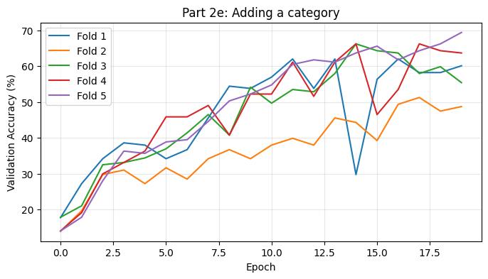

```python
# This adds Rotation and Color Jitter to fix the errors you found
improved_transform = transforms.Compose([
    transforms.RandomRotation(degrees=10),          # Improvement 1: Fix geometric issues
    transforms.ColorJitter(brightness=0.1, contrast=0.1), # Improvement 2: Fix lighting
    transforms.Resize((128, 128)),                  # Mandatory
    transforms.ToTensor(),
    transforms.Normalize(mean=[0.5, 0.5, 0.5], std=[0.5, 0.5, 0.5])
])



# Define custom model (Redefined to be safe)
class SimpleCNN(nn.Module):
    def __init__(self, num_classes):
        super(SimpleCNN, self).__init__()
        self.conv1 = nn.Conv2d(3, 32, kernel_size=3, padding=1)
        self.bn1 = nn.BatchNorm2d(32)
        self.relu = nn.ReLU()
        self.pool = nn.MaxPool2d(2, 2) # 128 -> 64

        self.conv2 = nn.Conv2d(32, 64, kernel_size=3, padding=1)
        self.bn2 = nn.BatchNorm2d(64)
        self.pool = nn.MaxPool2d(2, 2) # 64 -> 32 (Applied twice in forward)

        self.conv3 = nn.Conv2d(64, 128, kernel_size=3, padding=1)
        self.bn3 = nn.BatchNorm2d(128)

        # Flatten size calculation:
        # Input 128x128.
        # After Pool 1: 64x64.
        # After Pool 2: 32x32.
        # After Pool 3: 16x16.
        # Final Channels: 128.
        # Flattened = 128 * 16 * 16
        self.flatten = nn.Flatten()
        self.fc1 = nn.Linear(128 * 16 * 16, 512)
        self.fc2 = nn.Linear(512, num_classes)

    def forward(self, x):
        # We define pool explicitly here to match the layers above
        pool = nn.MaxPool2d(2, 2)
        x = pool(self.relu(self.bn1(self.conv1(x))))
        x = pool(self.relu(self.bn2(self.conv2(x))))
        x = pool(self.relu(self.bn3(self.conv3(x))))
        x = self.flatten(x)
        x = self.relu(self.fc1(x))
        x = self.fc2(x)
        return x

# Run training loop
dataset = WhaleDataset(df, TRAIN_DIR, transform=improved_transform)
kfold = StratifiedKFold(n_splits=K_FOLDS, shuffle=True, random_state=42)
device = torch.device("cuda" if torch.cuda.is_available() else "cpu")

fold_results_aug = {}
labels_list = df['label_idx'].tolist()

print(f"Starting Training on {device}...")

for fold, (train_ids, val_ids) in enumerate(kfold.split(df, labels_list)):
    print(f"\n--- AUGMENTED RUN | FOLD {fold+1}/{K_FOLDS} ---")

    train_sub = Subset(dataset, train_ids)
    val_sub = Subset(dataset, val_ids)
    train_loader = DataLoader(train_sub, batch_size=BATCH_SIZE, shuffle=True)
    val_loader = DataLoader(val_sub, batch_size=BATCH_SIZE, shuffle=False)

    # Dynamically get class count to match df
    num_classes = df['label_idx'].nunique()
    model = SimpleCNN(num_classes=num_classes).to(device)

    criterion = nn.CrossEntropyLoss()
    optimizer = optim.Adam(model.parameters(), lr=0.001)

    history = {'train_loss': [], 'val_acc': []}

    for epoch in range(NUM_EPOCHS):
        model.train()
        running_loss = 0.0
        for images, labels in train_loader:
            images, labels = images.to(device), labels.to(device)
            optimizer.zero_grad()
            outputs = model(images)
            loss = criterion(outputs, labels)
            loss.backward()
            optimizer.step()
            running_loss += loss.item()

        avg_train_loss = running_loss / len(train_loader)
        history['train_loss'].append(avg_train_loss)

        # Validation
        model.eval()
        correct = 0
        total = 0
        with torch.no_grad():
            for images, labels in val_loader:
                images, labels = images.to(device), labels.to(device)
                outputs = model(images)
                _, predicted = torch.max(outputs.data, 1)
                total += labels.size(0)
                correct += (predicted == labels).sum().item()

        val_acc = 100 * correct / total
        history['val_acc'].append(val_acc)
        print(f"Ep {epoch+1}: Val Acc {val_acc:.2f}%")

    fold_results_aug[fold] = history

final_fold_acc = []
final_fold_loss = []

for fold in fold_results_aug:
    fold_acc = fold_results_aug[fold]['val_acc'][-1]       # last epoch accuracy
    fold_loss = fold_results_aug[fold]['train_loss'][-1]   # last epoch loss
    final_fold_acc.append(fold_acc)
    final_fold_loss.append(fold_loss)

# Averages
mean_acc = np.mean(final_fold_acc)
mean_loss = np.mean(final_fold_loss)
print("FINAL CROSS-VALIDATION RESULTS")
print(f"Mean Cross-Validation Accuracy: {mean_acc:.4f}%")
print(f"Mean Cross-Validation Loss: {mean_loss:.4f}")

# Plot results
plt.figure(figsize=(8, 4))
for fold in fold_results_aug:
    plt.plot(fold_results_aug[fold]['val_acc'], label=f'Fold {fold+1}')
plt.title("Part 2e: Adding a category")
plt.xlabel("Epoch")
plt.ylabel("Validation Accuracy (%)")
plt.legend()
plt.grid(True, alpha=0.3)
plt.show()
```

# Part 3

**3a**

```python
from sklearn.model_selection import StratifiedKFold, train_test_split


# SETTINGS
EPOCHS_PHASE_1 = 5
EPOCHS_PHASE_2 = 5
LR_PHASE_1 = 0.001
LR_PHASE_2 = 0.0001

device = torch.device("cuda" if torch.cuda.is_available() else "cpu")
print("Using device:", device)

# transforms

transform = transforms.Compose([
    transforms.Resize((224, 224)),
    transforms.ToTensor(),
    transforms.Normalize(mean=[0.485, 0.456, 0.406],
                         std=[0.229, 0.224, 0.225])
])

# train / test split (10% test)
train_df, test_df = train_test_split(
    df,
    test_size=0.10,
    stratify=df["label_idx"],
    random_state=42
)

train_df = train_df.reset_index(drop=True)
test_df = test_df.reset_index(drop=True)

train_dataset = WhaleDataset(train_df, TRAIN_DIR, transform=transform)
test_dataset = WhaleDataset(test_df, TRAIN_DIR, transform=transform)
test_loader = DataLoader(test_dataset, batch_size=BATCH_SIZE, shuffle=False)

# MODEL BUILDER
def get_model_and_optimizer(model_name, num_classes, device):
    weights = "DEFAULT"

    if model_name == "resnet18":
        model = models.resnet18(weights=weights)
        for p in model.parameters():
            p.requires_grad = False
        model.fc = nn.Linear(model.fc.in_features, num_classes)
        params = model.fc.parameters()

    elif model_name == "densenet121":
        model = models.densenet121(weights=weights)
        for p in model.parameters():
            p.requires_grad = False
        model.classifier = nn.Linear(model.classifier.in_features, num_classes)
        params = model.classifier.parameters()

    elif model_name == "mobilenet_v2":
        model = models.mobilenet_v2(weights=weights)
        for p in model.parameters():
            p.requires_grad = False
        model.classifier[1] = nn.Linear(model.classifier[1].in_features, num_classes)
        params = model.classifier[1].parameters()

    elif model_name == "vgg16":
        model = models.vgg16(weights=weights)
        for p in model.parameters():
            p.requires_grad = False
        model.classifier[6] = nn.Linear(model.classifier[6].in_features, num_classes)
        params = model.classifier[6].parameters()

    model = model.to(device)
    optimizer = optim.Adam(params, lr=LR_PHASE_1)
    return model, optimizer

# Training pipeline
kfold = StratifiedKFold(n_splits=K_FOLDS, shuffle=True, random_state=42)
models_to_run = ["resnet18", "densenet121", "mobilenet_v2", "vgg16"]

results_table = []

for model_name in models_to_run:
    print("\n" + "="*50)
    print("RUNNING MODEL:", model_name.upper())
    print("="*50)

    best_fold_val_acc = 0
    best_fold_val_loss = None
    best_test_acc = None
    best_test_loss = None
    best_params = None
    unique_correct = None
    unique_errors = None

    labels = train_df["label_idx"].tolist()

    for fold, (train_idx, val_idx) in enumerate(kfold.split(train_df, labels)):
        print(f"\n--- FOLD {fold+1}/{K_FOLDS} ---")

        train_subset = Subset(train_dataset, train_idx)
        val_subset = Subset(train_dataset, val_idx)

        train_loader = DataLoader(train_subset, batch_size=BATCH_SIZE, shuffle=True)
        val_loader = DataLoader(val_subset, batch_size=BATCH_SIZE, shuffle=False)

        criterion = nn.CrossEntropyLoss()
        model, optimizer = get_model_and_optimizer(model_name, NUM_CLASSES_TO_USE, device)

        num_params = sum(p.numel() for p in model.parameters())

        # PHASE 1: Train head
        for epoch in range(EPOCHS_PHASE_1):
            model.train()
            for imgs, lbls in train_loader:
                imgs, lbls = imgs.to(device), lbls.to(device)
                optimizer.zero_grad()
                outputs = model(imgs)
                loss = criterion(outputs, lbls)
                loss.backward()
                optimizer.step()

        # PHASE 2: Fine tune
        for p in model.parameters():
            p.requires_grad = True
        optimizer = optim.Adam(model.parameters(), lr=LR_PHASE_2)

        best_this_fold_acc = 0
        best_this_fold_loss = None

        for epoch in range(EPOCHS_PHASE_2):
            model.train()
            for imgs, lbls in train_loader:
                imgs, lbls = imgs.to(device), lbls.to(device)
                optimizer.zero_grad()
                outputs = model(imgs)
                loss = criterion(outputs, lbls)
                loss.backward()
                optimizer.step()

            # VALIDATION
            model.eval()
            val_loss_sum = 0
            correct = 0
            total = 0

            with torch.no_grad():
                for imgs, lbls in val_loader:
                    imgs, lbls = imgs.to(device), lbls.to(device)
                    out = model(imgs)
                    loss = criterion(out, lbls)
                    val_loss_sum += loss.item() * lbls.size(0)
                    _, pred = torch.max(out, 1)
                    correct += (pred == lbls).sum().item()
                    total += lbls.size(0)

            val_loss = val_loss_sum / total
            val_acc = 100 * correct / total

            if val_acc > best_this_fold_acc:
                best_this_fold_acc = val_acc
                best_this_fold_loss = val_loss

        print(f"Fold {fold+1}  Best Val Acc = {best_this_fold_acc:.2f}%")

        # CHECK IF THIS FOLD IS THE BEST
        if best_this_fold_acc > best_fold_val_acc:
            best_fold_val_acc = best_this_fold_acc
            best_fold_val_loss = best_this_fold_loss
            best_params = num_params

            # RUN TEST SET
            model.eval()
            all_preds = []
            all_labels = []
            test_loss_sum = 0
            total = 0

            with torch.no_grad():
                for imgs, lbls in test_loader:
                    imgs, lbls = imgs.to(device), lbls.to(device)
                    out = model(imgs)
                    loss = criterion(out, lbls)
                    test_loss_sum += loss.item() * lbls.size(0)
                    _, pred = torch.max(out, 1)
                    all_preds.extend(pred.cpu().numpy())
                    all_labels.extend(lbls.cpu().numpy())
                    total += lbls.size(0)

            best_test_loss = test_loss_sum / total
            best_test_acc = 100 * sum(np.array(all_preds) == np.array(all_labels)) / total

            # UNIQUE CORRECT / ERRORS
            correct_ids = {i for i, (p, t) in enumerate(zip(all_preds, all_labels)) if p == t}
            error_ids = {i for i, (p, t) in enumerate(zip(all_preds, all_labels)) if p != t}
            unique_correct = len(correct_ids)
            unique_errors = len(error_ids)

    # saving results
    results_table.append({
        "model": model_name,
        "num_parameters": best_params,
        "val_loss": best_fold_val_loss,
        "val_accuracy": best_fold_val_acc,
        "test_loss": best_test_loss,
        "test_accuracy": best_test_acc,
        "unique_correct": unique_correct,
        "unique_errors": unique_errors
    })
```

```
Using device: cuda

==================================================
RUNNING MODEL: RESNET18
==================================================

--- FOLD 1/5 ---
Downloading: "https://download.pytorch.org/models/resnet18-f37072fd.pth" to /root/.cache/torch/hub/checkpoints/resnet18-f37072fd.pth
```